# Causal Inference with Observational Data

Confidence Intervals in Emulated Target Trials

11 Dec 2024

## Gold Standard of Causal Inference

- **Randomized control trials** are the gold standard of Causal Inference
- But, not always feasible
  - ethical limitations
  - practical limitations

→ more and more common to use **observational data**

## Problem with Observational Data

- **Why can’t we directly gain causal insights?**
  - Treatment assignment is **not randomized**
  - Eligibility and treatment start occur at **different time points**
  - Observational data is prone to **biases** (e.g. selection bias)

→ Led to the development of the **Target Trial Emulation** framework

## Target Trial Emulation

- **TTE aims to prevent introduction of biases in observational data**
- Researchers emulate a series of **trials**
- Core concept: **t₀ alignment**

→ **sequential** TTE

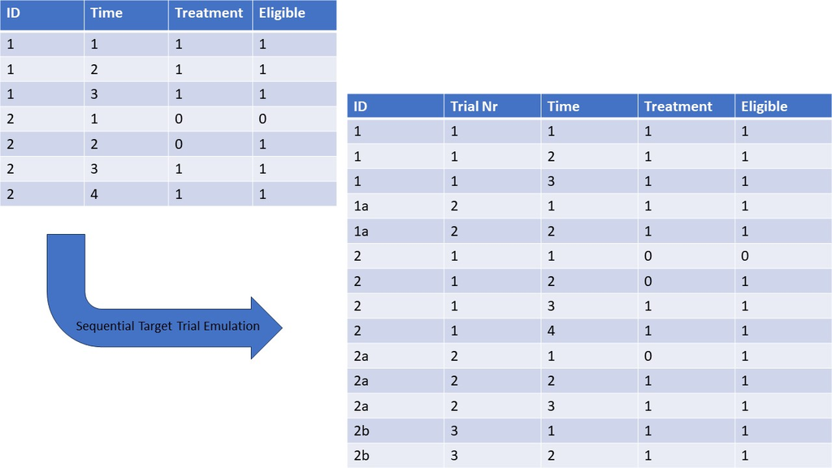

## Research Gap

- **Confidence Intervals** can’t be estimated directly anymore
  - one individual can be in multiple trials
  - IPW used for bias adjustments
- Literature recommends **non-parametric bootstrap**
- Two challenges:
  - **Computational efficiency** → `Julia`
  - **Sandwich-type** vs. **Bootstrap** variance estimation → Simulation Study

## Simulation Study

- First, development of a `Julia` package

`Julia` TTE package vs. existing `R` package

Sandwich-type vs. Bootstrap variance estimation

- Speed
- Memory usage
- Coverage
- Width of CI
- Type-I error rate
- Power

## Sources

[figure not shown]

Florian Metwaly

Austin, Peter C. 2016. “Variance Estimation When Using Inverse Probability of Treatment Weighting (IPTW) with Survival Analysis.” *Statistics in Medicine* 35 (30): 5642–55. https://doi.org/10.1002/sim.7084.

Fu, Edouard L. 2023. “Target Trial Emulation to Improve Causal Inference from Observational Data: What, Why, and How?” *Journal of the American Society of Nephrology* 34 (8): 1305. https://doi.org/10.1681/ASN.0000000000000152.

Hernan, Miguel A, and James M Robins. n.d. “Causal Inference: What If.”

Hernán, Miguel A. 2018. “How to Estimate the Effect of Treatment Duration on Survival Outcomes Using Observational Data.” *BMJ*, February, k182. https://doi.org/10.1136/bmj.k182.

Su, Li, Roonak Rezvani, Shaun R. Seaman, Colin Starr, and Isaac Gravestock. 2024. “TrialEmulation: An R Package to Emulate Target Trials for Causal Analysis of Observational Time-to-Event Data.” arXiv.